# Final Data Analysis Project

STAT 420, Fall 2024, Sports Ball

# Introduction

This project explores data from the Summer Olympic Games to understand what factors best predict an athlete’s likelihood of earning a medal. The data originates from the [Kaggle Olympic dataset](https://www.kaggle.com/datasets/heesoo37/120-years-of-olympic-history-athletes-and-results?resource=download) and consists of information on athletes, their demographics, physical attributes, participation history, and medal outcomes across all recorded Olympic Games.

For this analysis, we focus on male athletes who competed in Summer Olympic events from 2004 onwards. Variables of interest include:

- **Age**, **Height**, and **Weight:** Physical attributes hypothesized to influence performance
- **Podium:** A binary variable indicating whether the athlete earned a medal (1) or not (0).

The primary goal is to build a statistical model that predicts the probability of earning a medal based on physical characteristics. This analysis could provide insights for sports scientists, coaches, or aspiring athletes aiming to optimize performance.

# Methods

## Linear Model

### Data Preparation

The dataset was filtered to include only male athletes from Summer Games in or after 2004. Rows with missing values for `Age`, `Height`, and `Weight` were excluded.

A binary variable `Podium` was created to represent medal-winning outcomes, with 1 indicating a medal and 0 otherwise.

```
## tibble [29,717 × 16] (S3: tbl_df/tbl/data.frame)
##  $ ID    : num [1:29717] 2 23 34 51 51 51 51 51 51 55 ...
##  $ Name  : chr [1:29717] "A Lamusi" "Fritz Aanes" "Jamale (Djamel-) Aarrass (Ahrass-)" "Nstor Abad Sanjun" ...
##  $ Sex   : chr [1:29717] "M" "M" "M" "M" ...
##  $ Age   : num [1:29717] 23 26 30 23 23 23 23 23 23 26 ...
##  $ Height: num [1:29717] 170 187 187 167 167 167 167 167 167 170 ...
##  $ Weight: num [1:29717] 60 89 76 64 64 64 64 64 64 65 ...
##  $ Team  : chr [1:29717] "China" "Norway" "France" "Spain" ...
##  $ NOC   : chr [1:29717] "CHN" "NOR" "FRA" "ESP" ...
##  $ Games : chr [1:29717] "2012 Summer" "2004 Summer" "2012 Summer" "2016 Summer" ...
##  $ Year  : num [1:29717] 2012 2004 2012 2016 2016 ...
##  $ Season: chr [1:29717] "Summer" "Summer" "Summer" "Summer" ...
##  $ City  : chr [1:29717] "London" "Athina" "London" "Rio de Janeiro" ...
##  $ Sport : chr [1:29717] "Judo" "Wrestling" "Athletics" "Gymnastics" ...
##  $ Event : chr [1:29717] "Judo Men's Extra-Lightweight" "Wrestling Men's Light-Heavyweight, Greco-Roman" "Athletics Men's 1,500 metres" "Gymnastics Men's Individual All-Around" ...
##  $ Medal : chr [1:29717] NA NA NA NA ...
##  $ Podium: num [1:29717] 0 0 0 0 0 0 0 0 0 0 ...
```

### Modeling Approach

First, a linear regression model was used to predict `Podium` using Age, Height, and Weight as predictors.

The data was split into training (80%) and testing (20%) sets for validation.

Additional metrics were computed:

- **Train RMSE:** Evaluates model performance on the training set.
- **Adjusted $R^2$:** Measures how well the model explains the variability of the target variable, accounting for the number of predictors.
- **Test RMSE and Accuracy**

### Model Assumption Testing

- **Residual Normality:** Checked using a Q-Q plot and Shapiro-Wilk test for residuals.
- **Linearity:** Assessed by plotting residuals vs. predicted probabilities
- **Homoscedasticity:** Examined through a residuals plot

### Results

#### Intermediate Results

```
## [1] "Train RMSE: 0.348950557404522"
```

```
## [1] "Linear Model Adjusted R^2: 0.0126343128687304"
```

```
## [1] "Test RMSE: 0.348204365305721"
```

```
## [1] "Test Accuracy: 0.857142857142857"
```

#### Linear Model Assumptions

```
##
##  Shapiro-Wilk normality test
##
## data:  test_data[sample(nrow(test_data), 5000), ]$residuals
## W = 0.5293, p-value < 2.2e-16
```

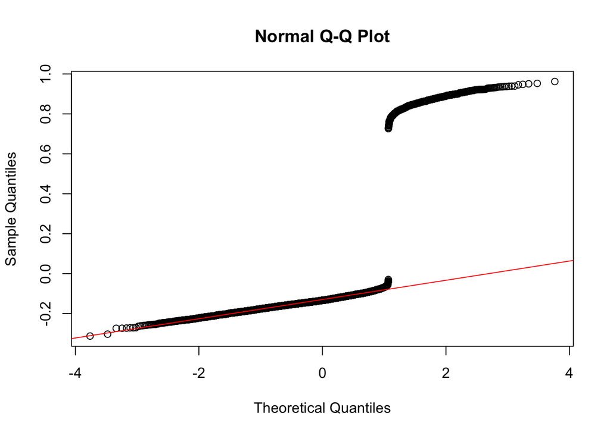

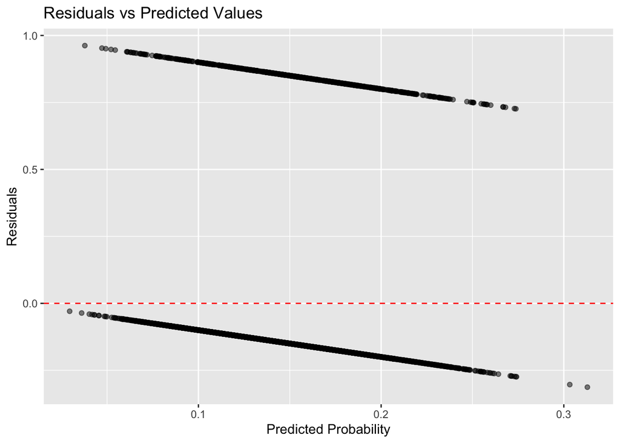

#### Possible Fixes?

First we find the Cook’s Distance of each observation that is considered large. A Cook’s Distance is considered large if $D_i > {4\over n}$.

We remove those values from our training data and create a similar linear model.

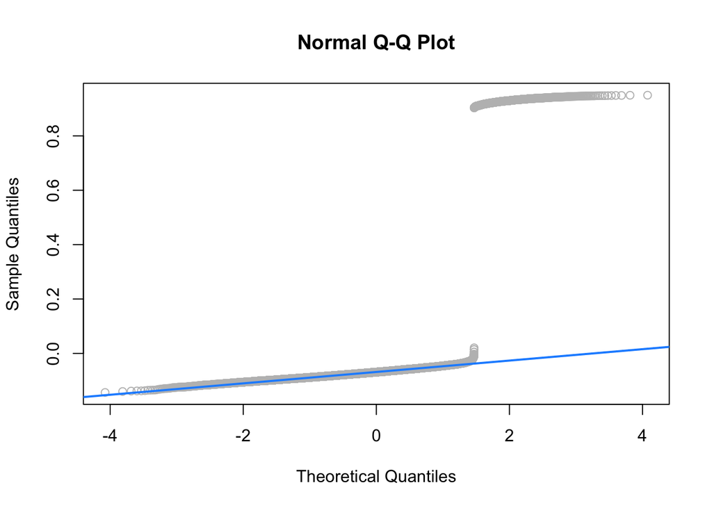

```
##
##  Shapiro-Wilk normality test
##
## data:  sample(resid(lin_mod_fix), 5000)
## W = 0.33699, p-value < 2.2e-16
```

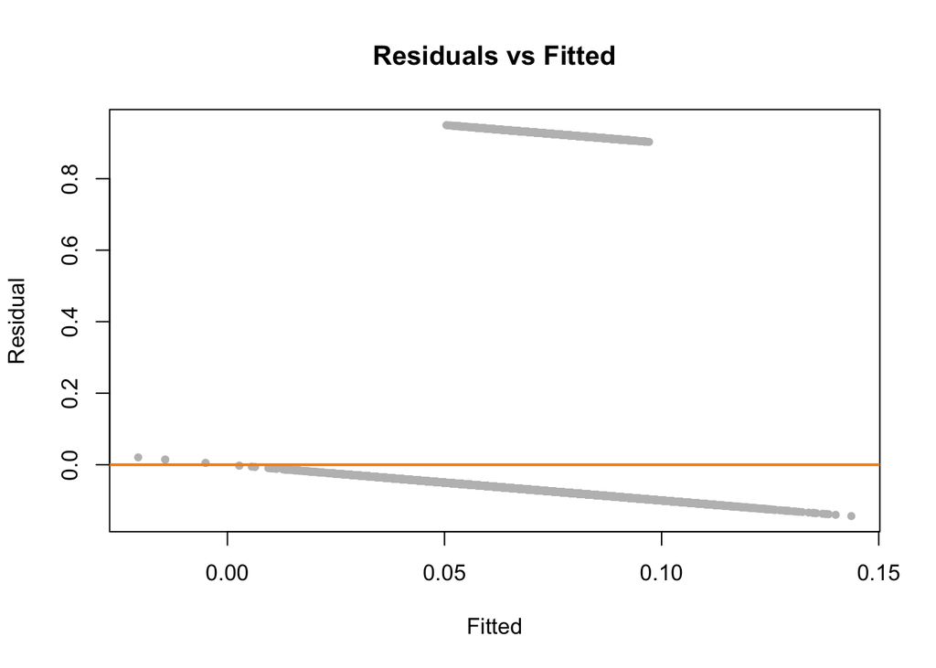

After attempting the fixes, we still see our assumptions are still violated. A linear model may not be the best choice, so a logistic model may show better results.